# Assignment 5. Dimensionality reduction techniques

```r
#libraries
library(dplyr)
```

```r
library(tidyr)
library(corrplot)
library(GGally)
library(ggplot2)
library(FactoMineR)
library(factoextra)
#just to be sure I downloaded the data
human <- read.table("https://raw.githubusercontent.com/KimmoVehkalahti/Helsinki-Open-Data-Science/master/datasets/human2.txt",
                    sep =",", header = T)
```

## Graphical examination of the data

As usual, the first step is to examine the data. Summaries of the variables and correlation matrix are provided, but as usual, the graphical examination is more illuminating and easier to interpret.

```r
#summaries and correlations
summary(human)
```

```
##     Edu2.FM          Labo.FM          Edu.Exp         Life.Exp
##  Min.   :0.1717   Min.   :0.1857   Min.   : 5.40   Min.   :49.00
##  1st Qu.:0.7264   1st Qu.:0.5984   1st Qu.:11.25   1st Qu.:66.30
##  Median :0.9375   Median :0.7535   Median :13.50   Median :74.20
##  Mean   :0.8529   Mean   :0.7074   Mean   :13.18   Mean   :71.65
##  3rd Qu.:0.9968   3rd Qu.:0.8535   3rd Qu.:15.20   3rd Qu.:77.25
##  Max.   :1.4967   Max.   :1.0380   Max.   :20.20   Max.   :83.50
##       GNI            Mat.Mor         Ado.Birth         Parli.F
##  Min.   :   581   Min.   :   1.0   Min.   :  0.60   Min.   : 0.00
##  1st Qu.:  4198   1st Qu.:  11.5   1st Qu.: 12.65   1st Qu.:12.40
##  Median : 12040   Median :  49.0   Median : 33.60   Median :19.30
##  Mean   : 17628   Mean   : 149.1   Mean   : 47.16   Mean   :20.91
##  3rd Qu.: 24512   3rd Qu.: 190.0   3rd Qu.: 71.95   3rd Qu.:27.95
##  Max.   :123124   Max.   :1100.0   Max.   :204.80   Max.   :57.50
```

```r
cor_matrix <- cor(human)

cor_matrix %>%
  round(2)
```

```
##           Edu2.FM Labo.FM Edu.Exp Life.Exp   GNI Mat.Mor Ado.Birth Parli.F
## Edu2.FM      1.00    0.01    0.59     0.58  0.43   -0.66     -0.53    0.08
## Labo.FM      0.01    1.00    0.05    -0.14 -0.02    0.24      0.12    0.25
## Edu.Exp      0.59    0.05    1.00     0.79  0.62   -0.74     -0.70    0.21
## Life.Exp     0.58   -0.14    0.79     1.00  0.63   -0.86     -0.73    0.17
## GNI          0.43   -0.02    0.62     0.63  1.00   -0.50     -0.56    0.09
## Mat.Mor     -0.66    0.24   -0.74    -0.86 -0.50    1.00      0.76   -0.09
## Ado.Birth   -0.53    0.12   -0.70    -0.73 -0.56    0.76      1.00   -0.07
## Parli.F      0.08    0.25    0.21     0.17  0.09   -0.09     -0.07    1.00
```

As can be seen in the graph below, most of the correlations are statistically significant. Additionally, some of the correlations are rather strong. For instance, the correlation between maternal mortality and life expectancy is -0.857. Correlation is generally considered to be strong if its value is larger than 0.7. However, this of course depends on the field of study and in social sciences, it is rather rare to observe correlations above 0.6. Therefore associations between the variables found in this dataset seem to have quite strong associations. Additionally, most of the distributions are quite linear, GNI and maternal mortality being an exception to this.

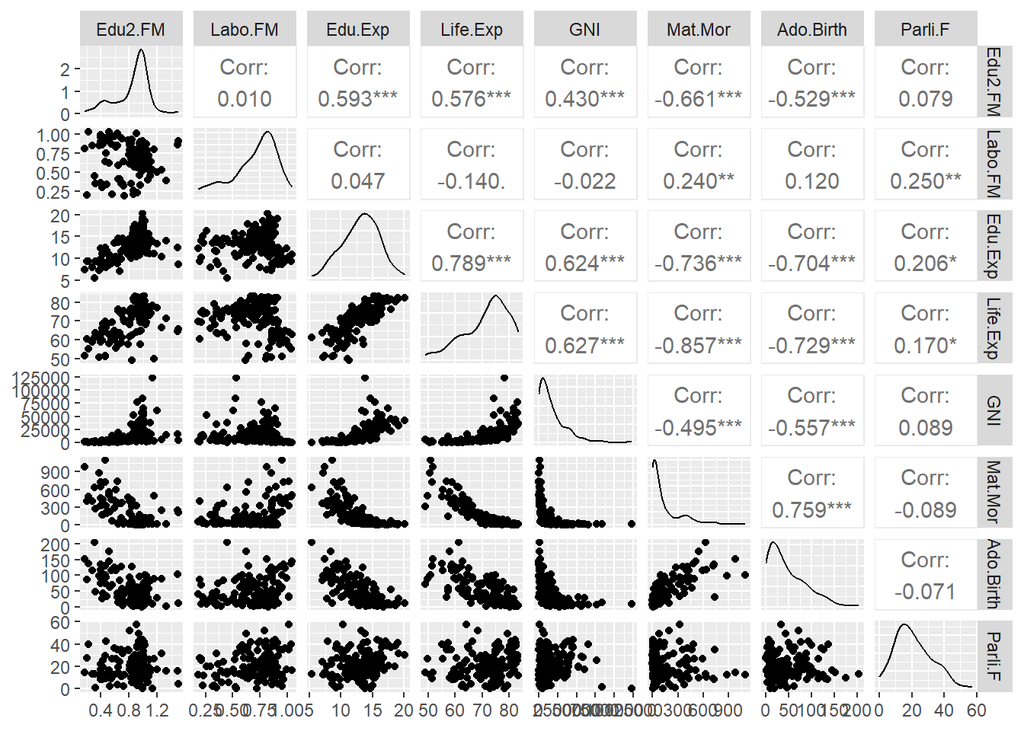

```r
#visualising the data

ggpairs(human)
```

```r
#pairs (human [-1], )
```

The second correlation plot highlights strong correlations in the data making them easier to observe. Only two variables, the percentage of female representation in parliament and the ratio between females and males in the labour force, do not have correlations with any other variables.

The strongest negative correlation is between the already mentioned life expectancy and maternal mortality. In other words, higher life expectancy is associated with lower maternal mortality. The strongest positive correlations seem to be found between expected years of schooling and life expectancy and between maternal mortality and adolescent birth rate. Hence higher life expectancy is associated with more expected years of schooling and a higher level of maternal mortality is associated with higher maternal mortality. In addition, expected years of schooling is associated with lower maternal mortality and a lower adolescent birth rate.

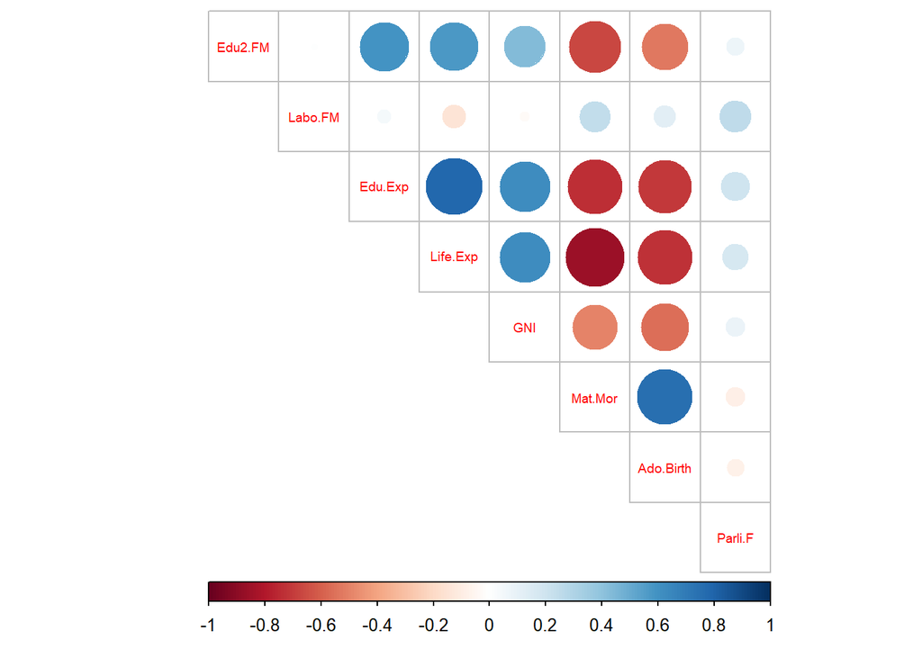

```r
corrplot(cor_matrix, method="circle", type ="upper",cl.pos = "b", tl.pos = "d", tl.cex = 0.6)
```

## Principal component analysis (PCA)

Principal component analysis (PCA) is a method to reduce the dimensionality of the data. This makes it easier to visualise and interpret while preserving the maximum amount of information. In order to do this, the technique transforms most of the variation in the data to fewer dimensions. These dimensions are then called principal components. Generally, the first two new dimensions are used to plot and then interpret the data.

In this case, the PCA is first done to the non-standardised data and then to the standardised version of the same data.

```r
pca_human <- prcomp(human)

s <- summary(pca_human)
s
```

```
## Importance of components:
##                              PC1      PC2   PC3   PC4   PC5   PC6    PC7    PC8
## Standard deviation     1.854e+04 185.5219 25.19 11.45 3.766 1.566 0.1912 0.1591
## Proportion of Variance 9.999e-01   0.0001  0.00  0.00 0.000 0.000 0.0000 0.0000
## Cumulative Proportion  9.999e-01   1.0000  1.00  1.00 1.000 1.000 1.0000 1.0000
```

```r
#pca_human

eigenvalues <- s$sdev^2
eigenvalues
```

```
## [1] 3.438860e+08 3.441836e+04 6.343853e+02 1.312035e+02 1.418457e+01
## [6] 2.452081e+00 3.655943e-02 2.531638e-02
```

```r
pca_pr <- round(1*s$importance[2, ], digits = 2)*100
# print out the percentages of variance
pca_pr
```

```
## PC1 PC2 PC3 PC4 PC5 PC6 PC7 PC8
## 100   0   0   0   0   0   0   0
```

The non-standardised data set produces quite interesting results: all variation in the data is assigned to the first principal component. Meaning there is only a single dimension found in the data.

[output not shown]

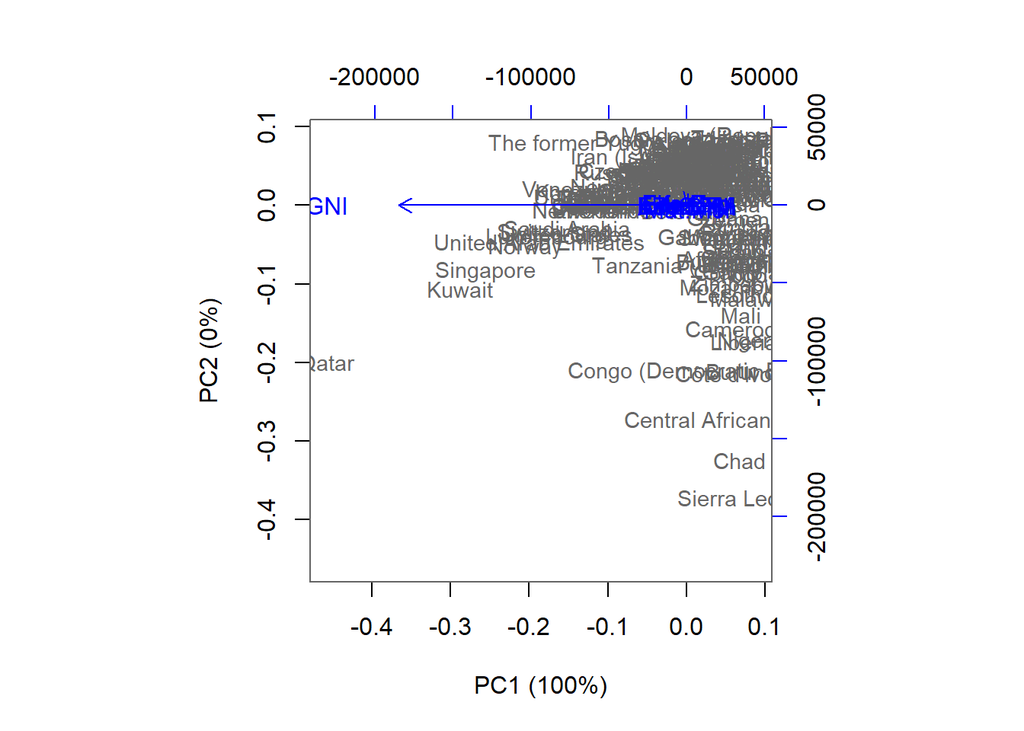

```r
#visualising the PCA results

#paste0(names(pca_pr), " (", pca_pr, "%)")

pc_lab <- paste0(names(pca_pr), " (", pca_pr, "%)")

# drawing a biplot
biplot(pca_human, cex = c(0.9, 1), col = c("grey40", "blue"), xlab = pc_lab[1], ylab = pc_lab[2])
```

The biplot has only one arrow, as the PCA did not manage to find more than one dimension (or principal component). Rstudio also notifies the user about this: “Warning: zero-length arrow is of indeterminate angle and so skipped”. The plot looks a bit funny, but probably standardising the data will help to produce more meaningful results.

## Principal component analysis (PCA) with a standardised dataset

```r
#standardising the data set
human_std <- scale(human)
summary(human_std)
```

```
##     Edu2.FM           Labo.FM           Edu.Exp           Life.Exp
##  Min.   :-2.8189   Min.   :-2.6247   Min.   :-2.7378   Min.   :-2.7188
##  1st Qu.:-0.5233   1st Qu.:-0.5484   1st Qu.:-0.6782   1st Qu.:-0.6425
##  Median : 0.3503   Median : 0.2316   Median : 0.1140   Median : 0.3056
##  Mean   : 0.0000   Mean   : 0.0000   Mean   : 0.0000   Mean   : 0.0000
##  3rd Qu.: 0.5958   3rd Qu.: 0.7350   3rd Qu.: 0.7126   3rd Qu.: 0.6717
##  Max.   : 2.6646   Max.   : 1.6632   Max.   : 2.4730   Max.   : 1.4218
##       GNI             Mat.Mor          Ado.Birth          Parli.F
##  Min.   :-0.9193   Min.   :-0.6992   Min.   :-1.1325   Min.   :-1.8203
##  1st Qu.:-0.7243   1st Qu.:-0.6496   1st Qu.:-0.8394   1st Qu.:-0.7409
##  Median :-0.3013   Median :-0.4726   Median :-0.3298   Median :-0.1403
##  Mean   : 0.0000   Mean   : 0.0000   Mean   : 0.0000   Mean   : 0.0000
##  3rd Qu.: 0.3712   3rd Qu.: 0.1932   3rd Qu.: 0.6030   3rd Qu.: 0.6127
##  Max.   : 5.6890   Max.   : 4.4899   Max.   : 3.8344   Max.   : 3.1850
```

```r
pca_human_std <- prcomp(human_std)
s <- summary(pca_human_std)
s
```

```
## Importance of components:
##                           PC1    PC2     PC3     PC4     PC5     PC6     PC7
## Standard deviation     2.0708 1.1397 0.87505 0.77886 0.66196 0.53631 0.45900
## Proportion of Variance 0.5361 0.1624 0.09571 0.07583 0.05477 0.03595 0.02634
## Cumulative Proportion  0.5361 0.6984 0.79413 0.86996 0.92473 0.96069 0.98702
##                            PC8
## Standard deviation     0.32224
## Proportion of Variance 0.01298
## Cumulative Proportion  1.00000
```

```r
#Eigenvectors
pca_human_std
```

```
## Standard deviations (1, .., p=8):
## [1] 2.0708380 1.1397204 0.8750485 0.7788630 0.6619563 0.5363061 0.4589994
## [8] 0.3222406
##
## Rotation (n x k) = (8 x 8):
##                   PC1         PC2         PC3         PC4        PC5
## Edu2.FM   -0.35664370  0.03796058 -0.24223089  0.62678110 -0.5983585
## Labo.FM    0.05457785  0.72432726 -0.58428770  0.06199424  0.2625067
## Edu.Exp   -0.42766720  0.13940571 -0.07340270 -0.07020294  0.1659678
## Life.Exp  -0.44372240 -0.02530473  0.10991305 -0.05834819  0.1628935
## GNI       -0.35048295  0.05060876 -0.20168779 -0.72727675 -0.4950306
## Mat.Mor    0.43697098  0.14508727 -0.12522539 -0.25170614 -0.1800657
## Ado.Birth  0.41126010  0.07708468  0.01968243  0.04986763 -0.4672068
## Parli.F   -0.08438558  0.65136866  0.72506309  0.01396293 -0.1523699
##                   PC6         PC7         PC8
## Edu2.FM    0.17713316  0.05773644  0.16459453
## Labo.FM   -0.03500707 -0.22729927 -0.07304568
## Edu.Exp   -0.38606919  0.77962966 -0.05415984
## Life.Exp  -0.42242796 -0.43406432  0.62737008
## GNI        0.11120305 -0.13711838 -0.16961173
## Mat.Mor    0.17370039  0.35380306  0.72193946
## Ado.Birth -0.76056557 -0.06897064 -0.14335186
## Parli.F    0.13749772  0.00568387 -0.02306476
```

```r
pca_pr <- round(1*s$importance[2, ], digits = 2)*100
# print out the percentages of variance
pca_pr
```

```
## PC1 PC2 PC3 PC4 PC5 PC6 PC7 PC8
##  54  16  10   8   5   4   3   1
```

This time the PCA seemed to work better: the variation is assigned to several principal components. The first component includes most of the variation: 54 %. The second component has an unmistakably smaller amount of variation: only 16 %.

```r
eigenvalues <- s$sdev^2
eigenvalues
```

```
## [1] 4.2883701 1.2989625 0.7657100 0.6066276 0.4381862 0.2876242 0.2106805
## [8] 0.1038390
```

Eigenvalues are used to determine the number of principal components. One rule of thumb recommends only using the principal components with eigenvalues that are greater than 1. In this case, the first two principal components fulfill this rule.

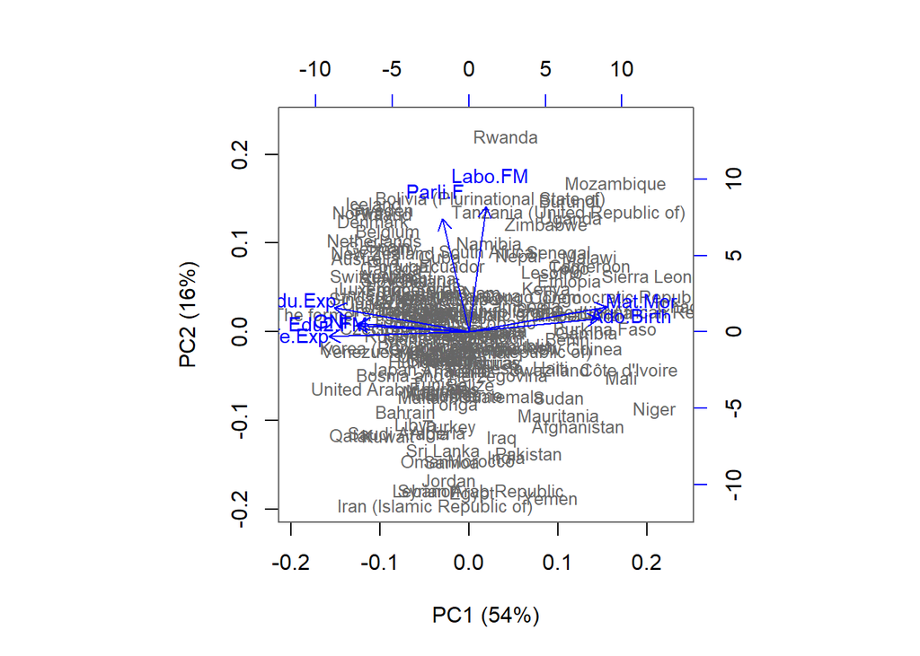

```r
#visualising the PCA results

#paste0(names(pca_pr), " (", pca_pr, "%)")

pc_lab <- paste0(names(pca_pr), " (", pca_pr, "%)")

# drawing a biplot
biplot(pca_human_std, cex = c(0.8, 0.9), col = c("grey40", "blue"), xlab = pc_lab[1], ylab = pc_lab[2])
```

Similarly, the biplot seems to be more sensible. The data points (=countries) are centered in the plot and all of the variables have their arrows visible.

However, the second analysis produces meaningful results. Maternal mortality and adolescent birth rate are positively associated with the first component. This can be seen in the biplot or from the eigenvectors. It seems that the first component deals with the health of the mother. The second component, on the other hand, is associated positively with the ratio of females and males in the workforce and the ratio of female representation in parliament. Therefore this component seems to be concerned with female participation in public life (as opposed to private life e.g. being a housewife etc.)

### Interpretations of the first two principal components

As mentioned above, the first principal component consists of maternal mortality and the adolescent birth rate which have a positive association with the component. Therefore, I would say that the component deals with the health of mothers. Possibly even ill health as the association is positive and both variables seem to concern negative effects (death and motherhood at a very young age).

The second principal component has also to do with women. This time the component has a positive correlation with the ratio of females vs, males in the workforce and the ratio of female representation in parliament. Hence, the second component seems to represent women’s attendance in public life: it has to do with women in the working life and the public sphere instead of private life (= at home).

## Multiple Correspondence Analysis

The next task uses a new dataset. This time the dataset concerns tea and tea-drinking habits. The data has 300 observations (=participants or individuals) and 36 variables. 18 variables concern tea-drinking preferences, 12 with their perception of tea and 4 variables deal with demographics and other personal details. Most of the variables are categorical with two or three levels.

```r
#preparing the data

tea <- read.csv("https://raw.githubusercontent.com/KimmoVehkalahti/Helsinki-Open-Data-Science/master/datasets/tea.csv", stringsAsFactors = TRUE)

#View(tea)
str(tea)
```

```
## 'data.frame':    300 obs. of  36 variables:
##  $ breakfast       : Factor w/ 2 levels "breakfast","Not.breakfast": 1 1 2 2 1 2 1 2 1 1 ...
##  $ tea.time        : Factor w/ 2 levels "Not.tea time",..: 1 1 2 1 1 1 2 2 2 1 ...
##  $ evening         : Factor w/ 2 levels "evening","Not.evening": 2 2 1 2 1 2 2 1 2 1 ...
##  $ lunch           : Factor w/ 2 levels "lunch","Not.lunch": 2 2 2 2 2 2 2 2 2 2 ...
##  $ dinner          : Factor w/ 2 levels "dinner","Not.dinner": 2 2 1 1 2 1 2 2 2 2 ...
##  $ always          : Factor w/ 2 levels "always","Not.always": 2 2 2 2 1 2 2 2 2 2 ...
##  $ home            : Factor w/ 2 levels "home","Not.home": 1 1 1 1 1 1 1 1 1 1 ...
##  $ work            : Factor w/ 2 levels "Not.work","work": 1 1 2 1 1 1 1 1 1 1 ...
##  $ tearoom         : Factor w/ 2 levels "Not.tearoom",..: 1 1 1 1 1 1 1 1 1 2 ...
##  $ friends         : Factor w/ 2 levels "friends","Not.friends": 2 2 1 2 2 2 1 2 2 2 ...
##  $ resto           : Factor w/ 2 levels "Not.resto","resto": 1 1 2 1 1 1 1 1 1 1 ...
##  $ pub             : Factor w/ 2 levels "Not.pub","pub": 1 1 1 1 1 1 1 1 1 1 ...
##  $ Tea             : Factor w/ 3 levels "black","Earl Grey",..: 1 1 2 2 2 2 2 1 2 1 ...
##  $ How             : Factor w/ 4 levels "alone","lemon",..: 1 3 1 1 1 1 1 3 3 1 ...
```

[output cut: 22 more lines]

```r
dim(tea)
```

```
## [1] 300  36
```

For this assignment, I decided to use only a small subset of the data. I assume, that interpreting the results is probably easier with a smaller amount of variables. Therefore I kept six variables that depict tea-drinking habits.

```r
# column names to keep in the dataset
keep_columns <- c("Tea", "How", "how", "sugar", "where", "lunch")

# select the 'keep_columns' to create a new dataset
tea_time <- tea[keep_columns]


#summaries and structure of the data
dim(tea_time)
```

```
## [1] 300   6
```

```r
str(tea_time)
```

```
## 'data.frame':    300 obs. of  6 variables:
##  $ Tea  : Factor w/ 3 levels "black","Earl Grey",..: 1 1 2 2 2 2 2 1 2 1 ...
##  $ How  : Factor w/ 4 levels "alone","lemon",..: 1 3 1 1 1 1 1 3 3 1 ...
##  $ how  : Factor w/ 3 levels "tea bag","tea bag+unpackaged",..: 1 1 1 1 1 1 1 1 2 2 ...
##  $ sugar: Factor w/ 2 levels "No.sugar","sugar": 2 1 1 2 1 1 1 1 1 1 ...
##  $ where: Factor w/ 3 levels "chain store",..: 1 1 1 1 1 1 1 1 2 2 ...
##  $ lunch: Factor w/ 2 levels "lunch","Not.lunch": 2 2 2 2 2 2 2 2 2 2 ...
```

```r
summary(tea_time)
```

```
##         Tea         How                      how           sugar
##  black    : 74   alone:195   tea bag           :170   No.sugar:155
##  Earl Grey:193   lemon: 33   tea bag+unpackaged: 94   sugar   :145
##  green    : 33   milk : 63   unpackaged        : 36
##                  other:  9
##                   where           lunch
##  chain store         :192   lunch    : 44
##  chain store+tea shop: 78   Not.lunch:256
##  tea shop            : 30
##
```

### Visual examination of the data

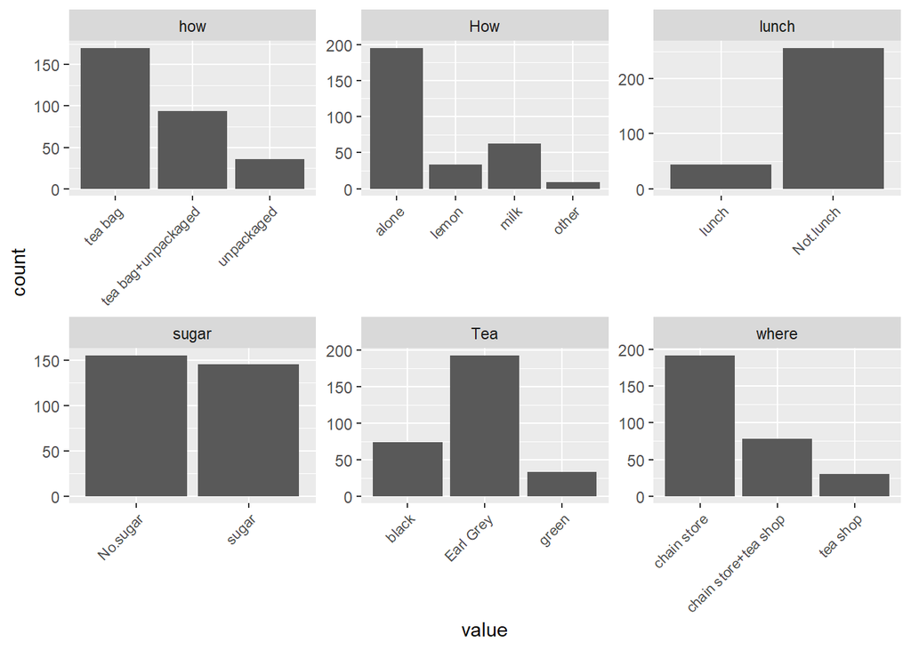

```r
# visualising the dataset
pivot_longer(tea_time, cols = everything()) %>%
  ggplot(aes(value)) + facet_wrap("name", scales = "free") +
 geom_bar() +
  theme(axis.text.x = element_text(angle = 45, hjust = 1, size = 8))
```

The graphs above illustrate the distributions of the variables. In most cases, there is a clear majority in preferences. For example, the most common type of tea seems to be Earl Grey and the most common way to prepare tea seems to be using tea bags. The only variable with almost equal distribution is the usage of sugar.

### Multiple correspondence analysis

Multiple correspondence analysis (MCA) is a technique to analyse nominal categorical data. It is used to detect and portray underlying structures in a dataset and it resembles PCA. The results of MCA are often represented as a two-dimensional “map”.

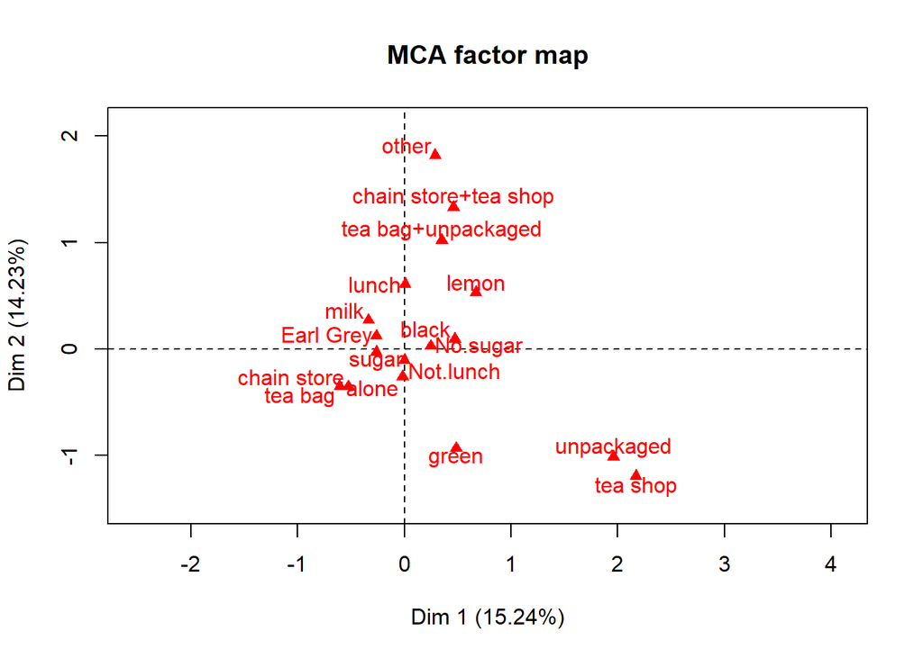

```r
# multiple correspondence analysis
mca <- MCA(tea_time, graph = FALSE)

# summary of the model
#mca
#mca$eig

# visualize MCA
plot(mca, invisible=c("ind"), graph.type = "classic")
```

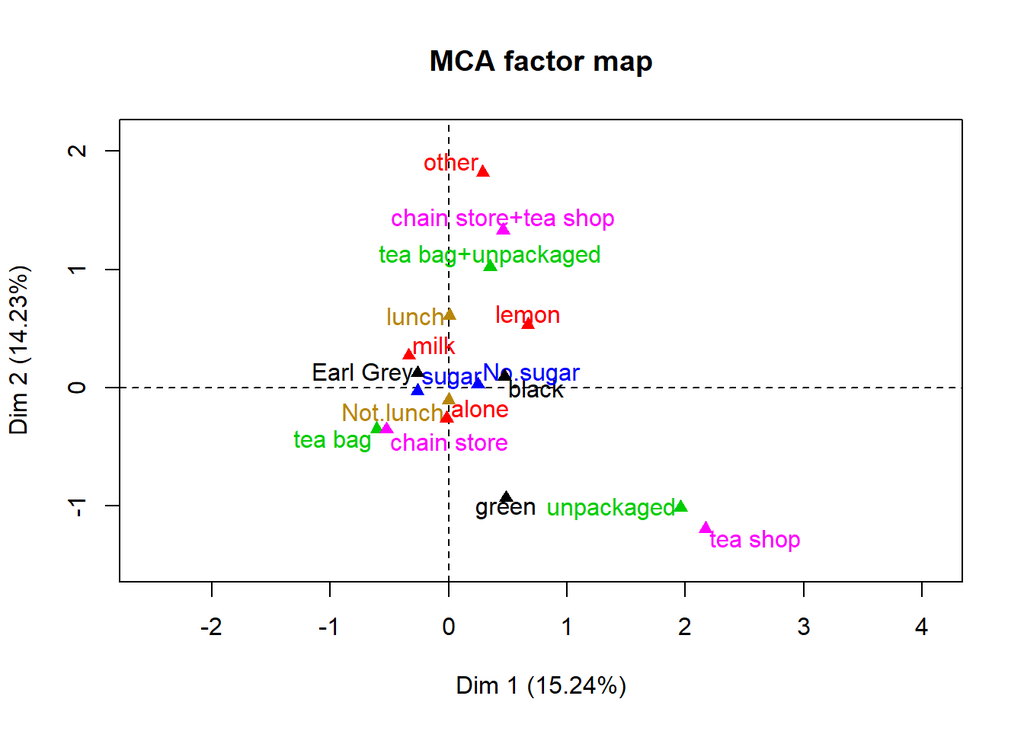

```r
plot(mca, invisible=c("ind"), graph.type = "classic", habillage = "quali")
```

The first plot has variables and their levels drawn as clusters within two dimensions. The second plot is otherwise the same, but the levels of the variables share a colour. For example, different tea types are drawn with black ink and the place of purchase uses pink ink.

It seems that unpackaged tea is most often bought from tea shops (no big surprises here). Another cluster is at the top of the plot. It seems to concern flexible or undecided people, depending on your point of view. The favourite place to buy tea is both chain store and tea shop. Similarly, these people drink both unpackaged tea and tea from tea bags. The third cluster is in the bottom left. here the favoured way to buy tea is tea bags from chain stores. Additionally, this tea is drunk without adding anything. Lastly, it seems that black tea is most often drunk without sugar.

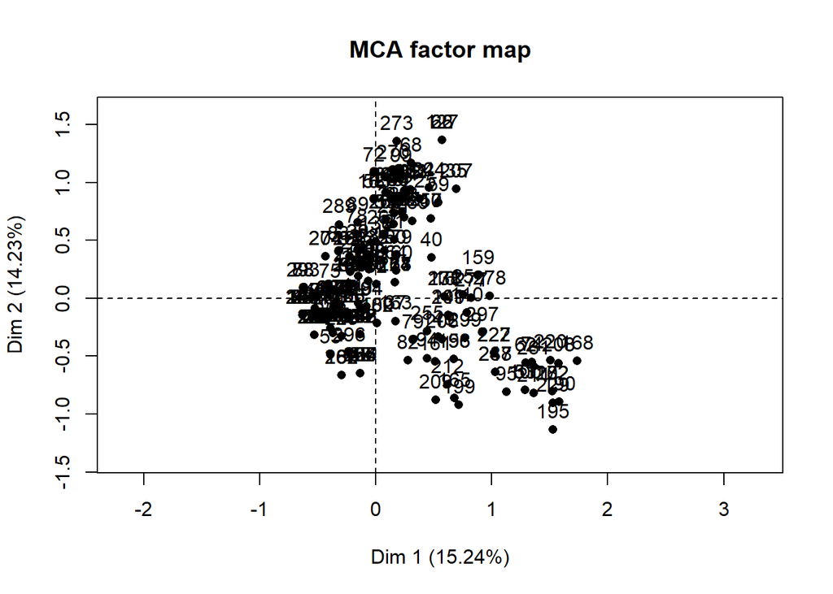

```r
plot(mca, invisible=c("var"), graph.type = "classic")
```

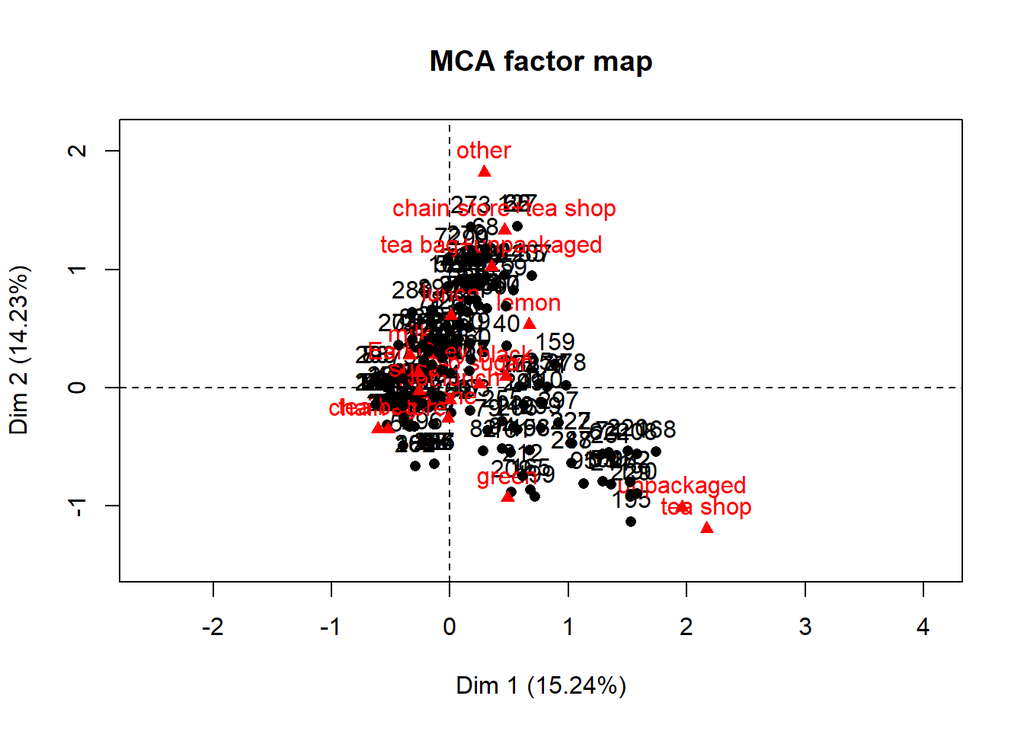

```r
plot(mca, invisible=c("none"), graph.type = "classic")
```

The next plot has the observations or individuals in it. The plot after that has both individuals and variables.

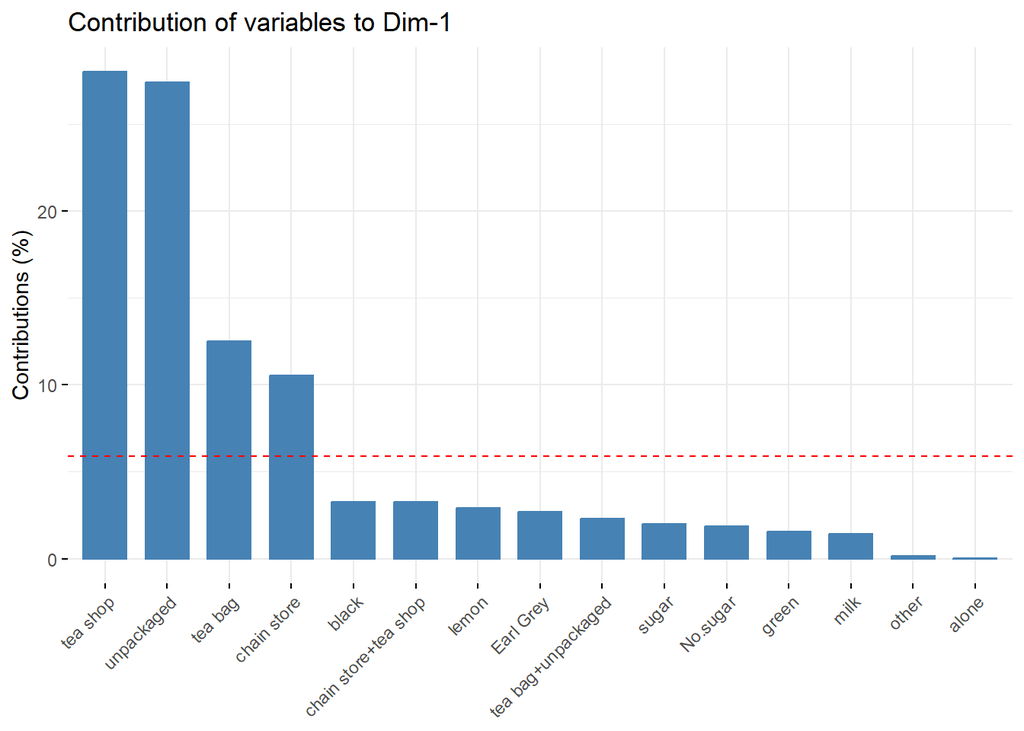

```r
fviz_contrib(mca, choice = "var", axes = 1, top = 15)
```

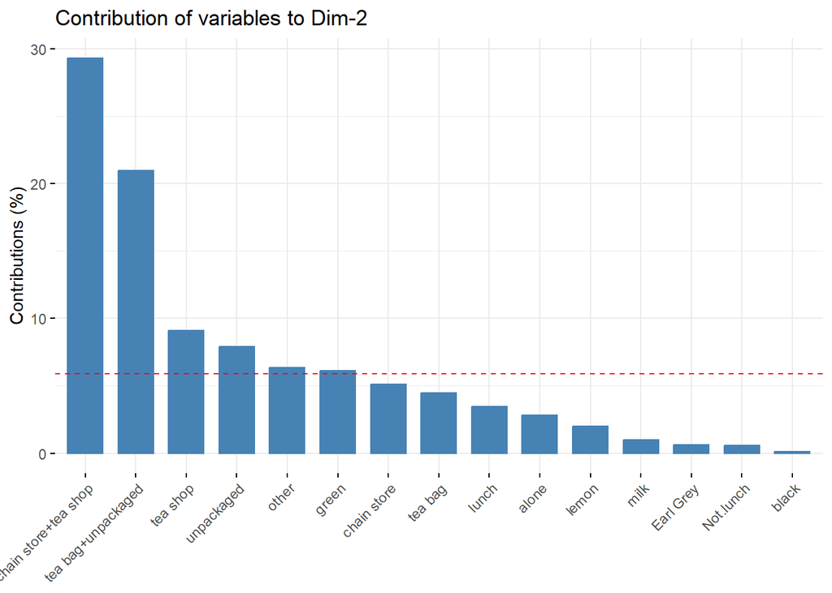

```r
# Contributions of rows to dimension 2
fviz_contrib(mca, choice = "var", axes = 2, top = 15)
```

These two plots kinda confirm my previous interpretation. The plots show us how different variables contribute to dimensions one and two. The first one has a tea shop and unpackaged tea as its main components. Dimension two on the other hand has a chain store + tea shop and tea bag + unpackaged tea as its main contributors.

The last plots depict the individuals by groups using the levels of the variables. Some of these groupings produce clearer results than the rest. For example, there seems to be a clear division between the place of purchase (“where”). The same applies to the type of tea purchased (bags, unpackaged, both). On the other hand, how the tea is drunk (alone, with lemon, with milk, or other) does not seem to cluster that well. Sugar or no sugar and whether the tea is drunk at lunch have the same issue.

In conclusion, it seems that the place of purchase and the type of the purchases (tea bags, unpackaged or both) form the clearest cluster in this data. Not surprisingly, unpackaged tea is often bought from tea shops and tea bags are bought from chain stores.

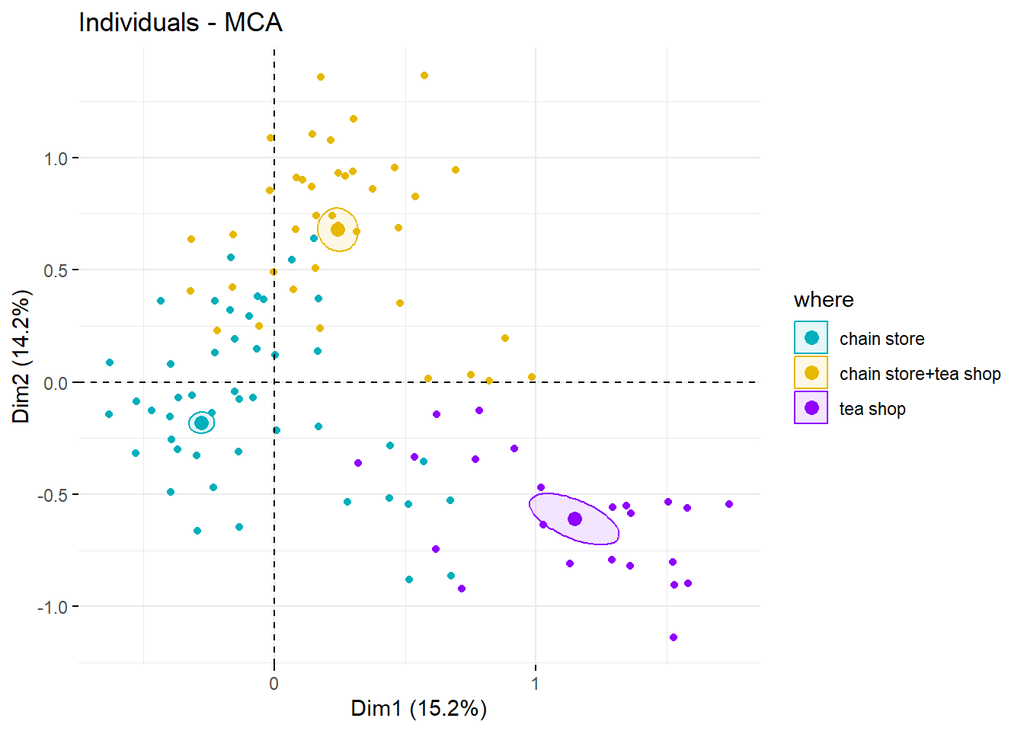

```r
fviz_mca_ind(mca,
             label = "none", # hide individual labels
             habillage = "where", # color by groups
             palette = c("#00AFBB", "#E7B800", "#8f00ff"),
             addEllipses = TRUE, ellipse.type = "confidence",
             ggtheme = theme_minimal())
```

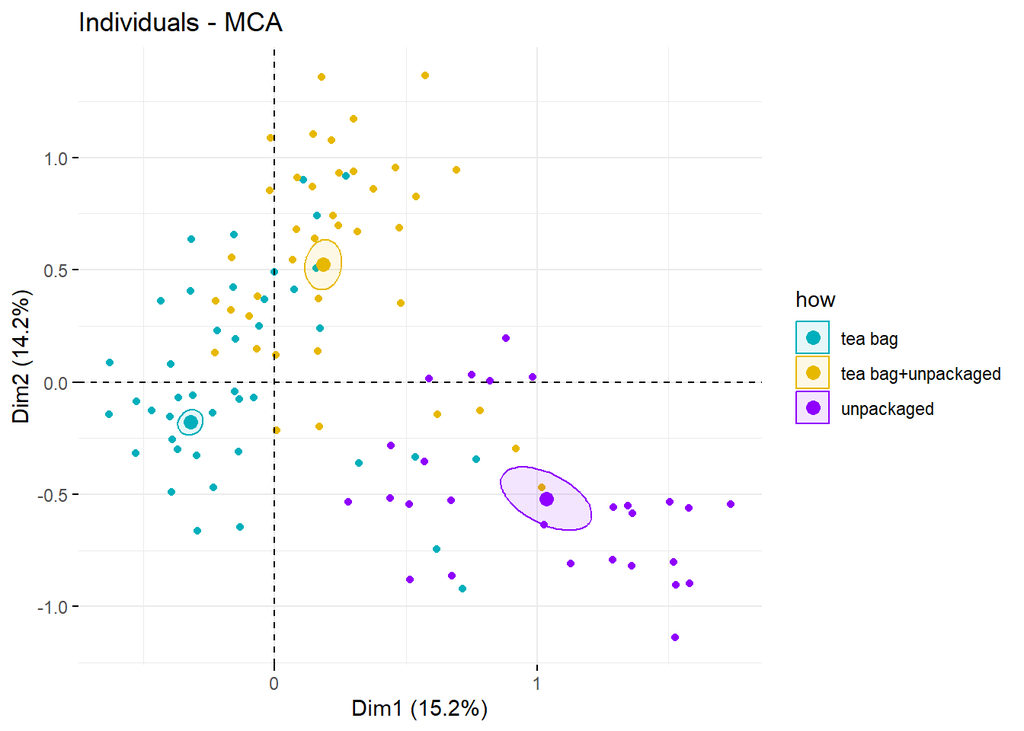

```r
fviz_mca_ind(mca,
             label = "none", # hide individual labels
             habillage = "how", # color by groups
             palette = c("#00AFBB", "#E7B800", "#8f00ff"),
             addEllipses = TRUE, ellipse.type = "confidence",
             ggtheme = theme_minimal())
```

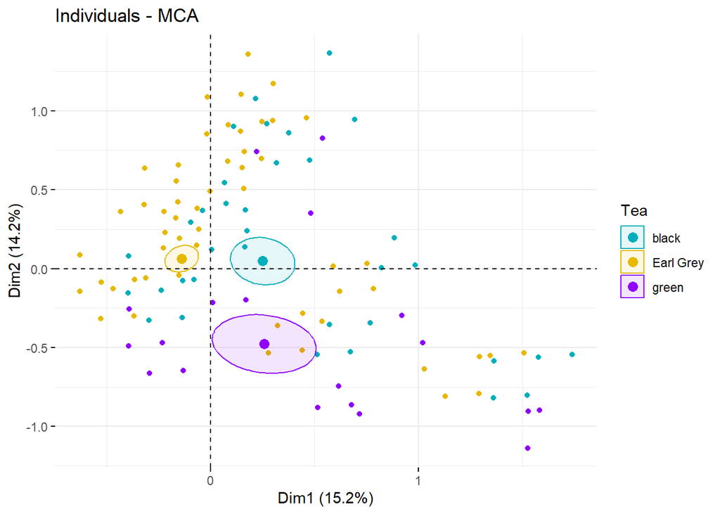

```r
fviz_mca_ind(mca,
             label = "none", # hide individual labels
             habillage = "Tea", # color by groups
             palette = c("#00AFBB", "#E7B800", "#8f00ff"),
             addEllipses = TRUE, ellipse.type = "confidence",
             ggtheme = theme_minimal())
```

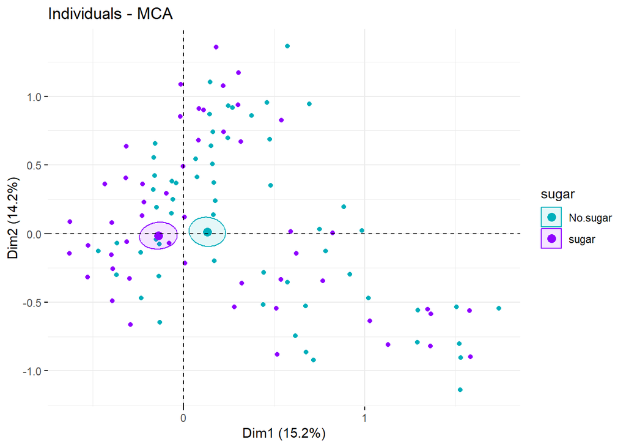

```r
fviz_mca_ind(mca,
             label = "none", # hide individual labels
             habillage = "sugar", # color by groups
             palette = c("#00AFBB", "#8f00ff"),
             addEllipses = TRUE, ellipse.type = "confidence",
             ggtheme = theme_minimal())
```

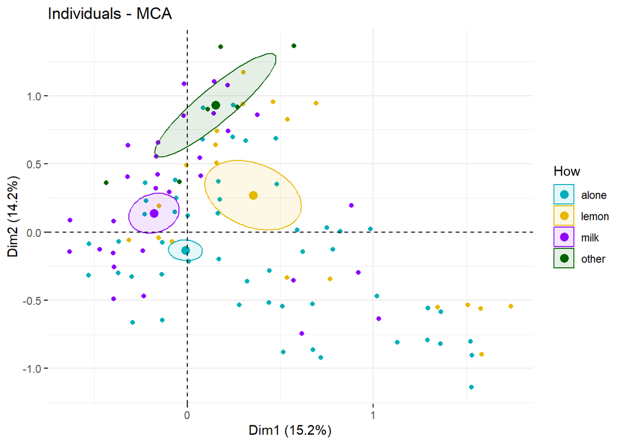

```r
fviz_mca_ind(mca,
             label = "none", # hide individual labels
             habillage = "How", # color by groups
             palette = c("#00AFBB", "#E7B800", "#8f00ff", "#006400"),
             addEllipses = TRUE, ellipse.type = "confidence",
             ggtheme = theme_minimal())
```

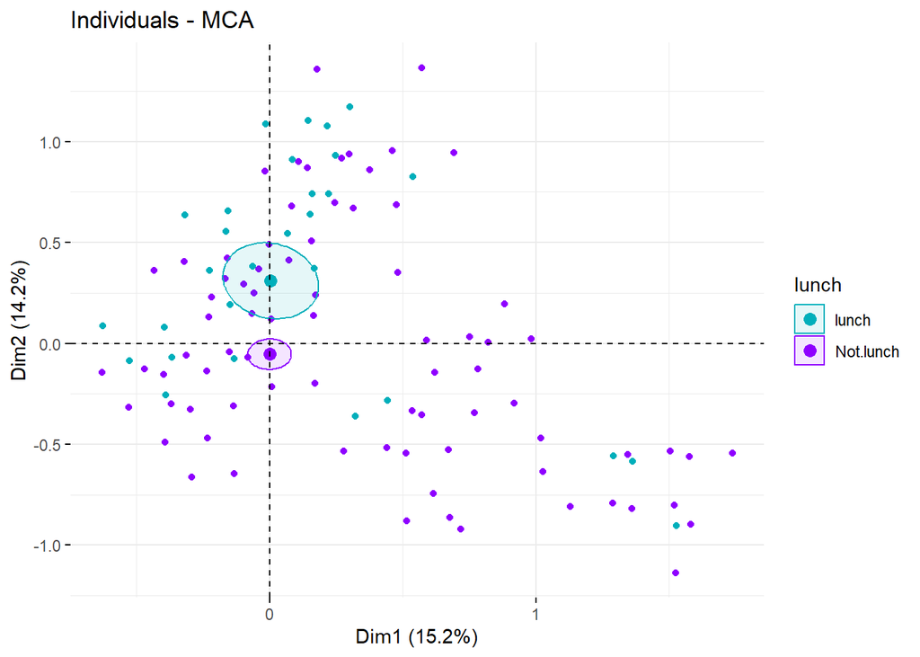

```r
fviz_mca_ind(mca,
             label = "none", # hide individual labels
             habillage = "lunch", # color by groups
             palette = c("#00AFBB", "#8f00ff"),
             addEllipses = TRUE, ellipse.type = "confidence",
             ggtheme = theme_minimal())
```